# MCBD Survey 1 Cleanup and Summaries

Veronica F. Frans, CSIS Lab, Michigan State University

May 19, 2020 (Updated: September 4, 2020)

# 1. Methods summary

Synthesis of survey 1 results for metacoupling/biodiversity systematic review. It consists of error checks, response summaries, numbers of papers for each stage of the PRISMA framework, and visualizations of the accepted papers.

# 2. R Setup

The script presented here was done using R (version 4.0.2; R Core Team 2020) and its packages.

Load libraries, directories, and custom functions from source file.

```r
# Source file
  source('Reference.R')
```

Data is stored here:

```
## [1] "C:/Users/niqui/OneDrive - Michigan State University/My Projects/Biodiv_Metacoupling/MCBD_Root/MCBD/data/"
```

Final tables are stored here:

```
## [1] "C:/Users/niqui/OneDrive - Michigan State University/My Projects/Biodiv_Metacoupling/MCBD_Root/MCBD/results/"
```

Final figures are stored here:

```
## [1] "C:/Users/niqui/OneDrive - Michigan State University/My Projects/Biodiv_Metacoupling/MCBD_Root/MCBD/images/"
```

For **this run** of the script, tables for manual checks will be stored in the following folder:

```
## [1] "C:/Users/niqui/OneDrive - Michigan State University/My Projects/Biodiv_Metacoupling/MCBD_Root/MCBD/issues/2020-09-04/"
```

# 3. Load data

```r
# load previous workspace (if needed)
  #load("Survey1Results.RData")

# survey
  survey1 <- read.csv(paste0(dat.dir,'survey_cleanup\\survey1_for_cleanup.csv'))

# 5 common surveys (no changes since version 4)
  survey1.5 <- read.csv(paste0(dat.dir,
                        'common_papers\\survey1_5_common_paper_selection_090120.csv'))

# assignment sheet
  assignments <- read.csv(paste0(dat.dir,
                                 'absScreening\\Coding_MergeAssign_R1.csv'))

# abstract screening
  ab_screen <- read.csv(paste0(dat.dir,
                               'absScreening\\AbsScreen1_Merge.csv'))
  ab_maybes <- read.csv(paste0(dat.dir,
                               'absScreening\\AbsScreen2_maybes_to_keep.csv'))
  ab_yeses <- read.csv(paste0(dat.dir,
                              'absScreening\\final_sample_for_coding.csv'))
```

# 4. Data cleanup

## 4.1 Data preview

Merge survey 1 with the 5 common paper survey result.

```r
survey1 <- bind_rows(survey1,survey1.5)
```

Quick summary of the dataset.

```r
# number entries
  paste('number of entries:',nrow(survey1))

# number columns
  paste('number of columns:',ncol(survey1))

# column names
  paste('column names:')
  colnames(survey1)

# number of unique papers surveyed
  paste('number of papers:',length(unique(survey1$paper_id)))

# number of observers
  paste('number of observers:',length(unique(survey1$coder_id)))

# list of observers
  paste('observer names:')
  paste(unique(survey1$coder_id),collapse="; ")
```

```
## [1] "number of entries: 591"
## [1] "number of columns: 16"
## [1] "column names:"
##  [1] "timestamp"                "coder_id"
##  [3] "paper_id"                 "year_pub"
##  [5] "author"                   "C1_biodiv"
##  [7] "C2_meta"                  "C3_quant"
##  [9] "C4_study"                 "meet_all_4"
## [11] "sup_check"                "comments"
## [13] "further_discuss"          "explicit_distant_impacts"
## [15] "explain_distant_impacts"  "status"
## [1] "number of papers: 591"
## [1] "number of observers: 13"
## [1] "observer names:"
## [1] "E_Dean; E_Xing; MG_Chung; M_Lei; C_Hovis; Y_Zhang; A_Herzberger; X_Wu; A_Torres; K_Kapsar; Y_Li; Y_Dou; all"
```

The expected number of papers surveyed should be **593** (plus or minus 2 with duplicated study IDs 379 and 501).

## 4.2 Editing each column

First, we change the the paper ID numbers in the assignment sheet for those with duplicate IDs that have been changed in the surveys.

```r
# change paper ID based on original ID and coder
  assignments$STUDY_ID.1[assignments$STUDY_ID.1==501 &
                           assignments$REVIEWERS=='EmilyX'] <-5010002
  assignments$STUDY_ID.1[assignments$STUDY_ID.1==501 &
                           assignments$REVIEWERS=='Yuqian'] <- 5010001
  assignments$STUDY_ID.1[assignments$STUDY_ID.1==379 &
                           assignments$REVIEWERS=='Ruishan'] <- 3790002
```

### 4.2.1 Publication years

There are some typos in publication years. The publication years for each paper ID will thus be replaced with those from the assignment sheet.

```r
# get list of values to replace
  pID <- unique(survey1$paper_id)

# replace years
  for (i in 1:length(pID)){
      survey1$year_pub[survey1$paper_id==pID[[i]]] <-
      assignments$PY[assignments$STUDY_ID.1==pID[[i]]]
  }
```

## 4.2.2 Author names

Some author names have also been recorded incorrectly. Here, we copy the author list from the assignment sheet to replace all the author entries in the survey.

```r
# change to character
  assignments$AU <- as.character(assignments$AU)
  survey1$author <- as.character(survey1$author)

# replace author names
  for (i in 1:length(pID)){
      aut <- str_split(assignments$AU[assignments$STUDY_ID.1==pID[[i]]],";")[[1]][1]
      survey1$author[survey1$paper_id==pID[[i]]] <- aut
  }
```

### 4.2.3 Criteria 1 (Accepted papers only)

For this column and all subsequent columns, we only need to focus our edits on the accepted papers.

```r
# drop rejects
  keep <-  subset(survey1, status=='accept')

# antijoin for rejects (to be combined later)
  reject <- anti_join(survey1,keep)
```

Get unique values across columns

```r
# drop levels
  keep <- droplevels(keep)

# unique criteria 1s
  #unique(keep$C1_biodiv)
  length(unique(keep$C1_biodiv))
```

```
## [1] 122
```

These are **too unique to clean up**. Perhaps better results can be taken from survey2. This is a problem with open-ended questions.

### 4.2.4 Criteria 2 (Accepted papers only)

Get unique values across columns

```r
# unique criteria 2s
  #unique(keep$C2_meta)
  length(unique(keep$C2_meta))
```

```
## [1] 99
```

Again, **too unique to clean up**.

### 4.2.5 Criteria 3 (Accepted papers only)

Get unique values across columns

```r
# unique criteria 3s
  #unique(keep$C3_quant)
  length(unique(keep$C3_quant))
```

```
## [1] 125
```

Again, **too unique to clean up**. Reserve for now.

### 4.2.6 Criteria 4 (Accepted papers only)

Get unique values across columns

```r
# unique criteria 4s
  keep$C4_study <- as.factor(keep$C4_study)
  levels(keep$C4_study)
  length(unique(keep$C4_study))
```

```
## [1] "Experimental study"
## [2] "Interview"
## [3] "Mixed: both observational/experimental study and literature review"
## [4] "Modeling study (using empirical data and not projected)"
## [5] "Observational study"
## [6] "Observational/Modeling study"
## [1] 6
```

Show the entries for each of these study types and correct as needed.

```r
# "Experimental study"
  keep[keep$C4_study==levels(keep$C4_study)[1],]
```

|  | timestamp | coder_id | paper_id | year_pub | author | C1_biodiv | C2_meta | C3_quant | C4_study | meet_all_4 | sup_check | comments | further_discuss | explicit_distant_impacts | explain_distant_impacts | status |
| --- | --- | --- | --- | --- | --- | --- | --- | --- | --- | --- | --- | --- | --- | --- | --- | --- |
| 11 | 2020-04-16 12:06:26 | Y_Zhang | 311 | 2013 | FARRIS E | Dune plants | Tourist trampling impact on plant species cover | species cover | Experimental study | Yes | No Supplementary Material Provided |  | No | Yes |  | accept |
| 24 | 2020-03-16 12:19:18 | MG_Chung | 654 | 2018 | ANTONIO DONAZAR JOSE | avian acavengers | They studied how roads and the associated traffic intensity due to recreational activities influence natural ecological processes within a scavenger guild. | the number of scavenger species | Experimental study | Yes | Yes |  |  |  |  | accept |
| 83 | 2020-03-18 12:14:32 | MG_Chung | 4132 | 2014 | BJERKE J W | the Svalbard-breeding population of pink-footed goose (Anser brachyrhynchus) | the impacts of goose grazing on hay biomass and quality (diary grassland for farmers) | the Shannon biodiversity index | Experimental study | Yes | No Supplementary Material Provided |  |  |  |  | accept |
| 97 | 2020-04-30 21:27:18 | M_Lei | 4832 | 2013 | SILCOCK JENNY L | Arid vegetation in South Australia | grazing | richness and abundance | Experimental study | Yes | No Supplementary Material Provided |  | No | No | Grazing involves the movement of feeding animals | accept |

```r
# "Interview"
  keep[keep$C4_study==levels(keep$C4_study)[2],]
```

|  | timestamp | coder_id | paper_id | year_pub | author | C1_biodiv | C2_meta | C3_quant | C4_study | meet_all_4 | sup_check | comments | further_discuss | explicit_distant_impacts | explain_distant_impacts | status |
| --- | --- | --- | --- | --- | --- | --- | --- | --- | --- | --- | --- | --- | --- | --- | --- | --- |
| 114 | 2020-04-05 17:14:43 | X_Wu | 5853 | 2012 | FLECKS MORRIS | Turquoise dwarf gecko (Lygodactylus williamsi) | International pet trade | Population size | Interview | Yes | No Supplementary Material Provided |  | No | Yes |  | accept |

```r
# Edit as per email with coder
  keep$C4_study[keep$paper_id==5853] <- "Observational study"
```

“The estimation of gecko abundance is based on the combination of observational and survey data. I think it is sufficiently robust, and this paper met all the other criteria we established. So I would include this paper in the dataset and recode the study type as”observational" (because it has at least the observational component)"

```r
# "Mixed: both observational/experimental study and literature review"
  keep[keep$C4_study==levels(keep$C4_study)[3],]
```

|  | timestamp | coder_id | paper_id | year_pub | author | C1_biodiv | C2_meta | C3_quant | C4_study | meet_all_4 | sup_check | comments | further_discuss | explicit_distant_impacts | explain_distant_impacts | status |
| --- | --- | --- | --- | --- | --- | --- | --- | --- | --- | --- | --- | --- | --- | --- | --- | --- |
| 16 | 2020-04-28 22:17:00 | Y_Zhang | 425 | 2019 | COSTA LEONARDO LOPES | Tiger beetles (macroinvertebrates) | Tourism impacts on sand tiger beetle abundance | Tiger beetle abundance | Mixed: both observational/experimental study and literature review | Yes | Yes |  | No | No | Didn't specify where the tourists come from | accept |

```r
# Edit as per email with coder
  keep$C4_study[keep$paper_id==425] <- "Observational study"
```

```r
# "Modeling study (using empirical data and not projected)"
  keep[keep$C4_study==levels(keep$C4_study)[4],]
```

|  | timestamp | coder_id | paper_id | year_pub | author | C1_biodiv | C2_meta | C3_quant | C4_study | meet_all_4 | sup_check | comments | further_discuss | explicit_distant_impacts | explain_distant_impacts | status |
| --- | --- | --- | --- | --- | --- | --- | --- | --- | --- | --- | --- | --- | --- | --- | --- | --- |
| 1 | 2020-04-07 12:13:49 | E_Dean | 17 | 2019 | BRANDT JODI S | Forest cover | Tourism | Forest loss (change from forest to non-forest) | Modeling study (using empirical data and not projected) | Yes | No Supplementary Material Provided |  | No | Yes |  | accept |
| 15 | 2020-04-30 17:13:48 | M_Lei | 396 | 2019 | WRAITH JENNA | orchids richness in Australia | tourism and grazing | orchids richness | Modeling study (using empirical data and not projected) | Yes | No Supplementary Material Provided |  | No | Yes |  | accept |
| 23 | 2020-04-30 16:14:27 | M_Lei | 523 | 2018 | KOUVARI MIRANTA | mammals of extinction | human activity | extinct taxa | Modeling study (using empirical data and not projected) | Yes | Yes |  | No | Yes |  | accept |
| 34 | 2020-04-27 15:35:35 | C_Hovis | 1349 | 2017 | WALDRON ANTHONY | BD loss | Investment | percent bd lost/gained | Modeling study (using empirical data and not projected) | Yes | Yes |  | No | Yes |  | accept |
| 40 | 2020-03-31 13:52:42 | A_Torres | 1590 | 2017 | DALE VIRGINIA H | naturally generating forests | trade of woody pellets | extent of naturally generating forests and number of standing dead trees | Modeling study (using empirical data and not projected) | Yes | No |  |  | Yes | Exports of woody pellets from the southeastern United States (US) for European power plants | accept |
| 46 | 2020-03-31 14:43:09 | A_Torres | 1821 | 2017 | WILTING HARRY C | biodiversity footprint | global trade | mean species abundance | Modeling study (using empirical data and not projected) | Yes | Yes |  |  | Yes |  | accept |
| 51 | 2020-04-30 17:30:01 | M_Lei | 2284 | 2016 | SELIER SARAH-ANNE JEANETTA | the African elephant numbers in conservation area | tourist numbers | elephant numbers | Modeling study (using empirical data and not projected) | Yes | No Supplementary Material Provided |  | No | Yes |  | accept |
| 88 | 2020-04-06 10:53:29 | X_Wu | 4393 | 2013 | HANAFIAH MARLIA M | Freshwater native species | Species invasion | Species richness | Modeling study (using empirical data and not projected) | Yes | Yes | This paper mainly used secondary data. | No | Yes |  | accept |
| 118 | 2020-03-19 15:02:27 | MG_Chung | 5966 | 2012 | SIMOES VITULE JEAN RICARDO | fish fauna | biotic homogenization of fish fauna caused by the elimination of a natural barrier by a dam construction, aquacuture, aquarium trade | Jaccardâ\200\231s and Brayâ\200“Curtisâ\200\231s coefficients, Whittakerâ\200\231s beta diversity index, non-metric multidimensional scaling analysis (NMDS) and nonparametric tests | Modeling study (using empirical data and not projected) | Yes | Yes |  |  |  |  | accept |
| 125 | 2020-04-05 16:36:30 | E_Dean | 6502 | 2011 | NOCERA JOSEPH J | Abundance of grassland birds | Trade | Abundance of grassland birds | Modeling study (using empirical data and not projected) | Yes | No Supplementary Material Provided |  |  | Yes |  | accept |

[output cut: 1 more lines]

```r
# "Observational study"
  keep[keep$C4_study==levels(keep$C4_study)[5],]
```

|  | timestamp | coder_id | paper_id | year_pub | author | C1_biodiv | C2_meta | C3_quant | C4_study | meet_all_4 | sup_check | comments | further_discuss | explicit_distant_impacts | explain_distant_impacts | status |
| --- | --- | --- | --- | --- | --- | --- | --- | --- | --- | --- | --- | --- | --- | --- | --- | --- |
| 2 | 2020-03-19 13:14:33 | E_Xing | 44 | 2019 | MOKOTJOMELA THABISO M | vegetation intactness | Biodiversity Economy Strategy at South Africa | vegetation intactness | Observational study | Yes | No Supplementary Material Provided | It should be included and the former survey result about it should be omitted. | no such data in Chinese survey | yes | The properties which conduct Biodiversity Economy Strategy (BES) have high total vegetation intactness. That indicates that implementation of the BES is likely to assist in conserving biodiversity. | accept |
| 4 | 2020-04-30 18:34:55 | M_Lei | 80 | 2019 | KRAWCZYK ERIC | touristic development on Mediterranean island birds and reptile | buildings and roads | bird and reptile abundance | Observational study | Yes | Yes |  | No | Yes |  | accept |
| 5 | 2020-04-29 13:14:26 | C_Hovis | 84 | 2019 | LINDENMAYER DAVID B | Bird | Logging | apparent occupancy and richness | Observational study | Yes | Yes |  | No | No | Distant impact is logging, assuming that at least a portion of the logging is used to meet demand from distant places and not just for local communities | accept |
| 6 | 2020-04-28 18:33:54 | C_Hovis | 134 | 2017 | DUDLEY BRUCE D | Shrimp body condition and abundance | Species Invasion | body condition, habitat quality?, abundance | Observational study | Yes | No Supplementary Material Provided |  | No | No | Two invasive spp described as introduced, had to google to make sure introductions were related to TC. Minimal amount of inferring. | accept |
| 7 | 2020-04-16 11:18:16 | Y_Zhang | 227 | 2019 | MARQUARDT SANDRA G | Biodiveristy indicators (alpha, gamma) | Human consumption (direct, agriculture/land use) impact on biodiveristy footprint | Alpha (mean species abundance, relative abundance, relative within-sample species richness), gamma (vulnerability-weighted global relative species) | Observational study | Yes | Yes |  | No | No | No explicit discussion on distant impacts, but could infer human consumption (direct, agriculture/land use) and biodiveristy relationship | accept |
| 8 | 2020-08-31 14:35:40 | C_Hovis | 264 | 2019 | PINNA M S | Plant | tourism | indicies | Observational study | Yes | Yes |  | No | Yes | tourism included in "human impact" | accept |
| 9 | 2020-04-01 15:36:32 | A_Herzberger | 292 | 2019 | NOBRE REGINA L G | lake zooplankton & fish abundance | introduction of a fish | species richness | Observational study | Yes | Yes |  | No | Yes | a omnivores was introduced shortly after a mine opened up | accept |
| 10 | 2020-05-19 09:17:18 | X_Wu | 302 | 2014 | LIMA ANA CAROLINA | Fish | Tourism | Species richness; diversity; evenness; density | Observational study | Yes | No Supplementary Material Provided |  |  |  |  | accept |
| 12 | 2020-04-14 11:35:42 | E_Dean | 339 | 2013 | OLDEKOP JOHAN A | Ferns and leaf litter frogs | Market forces (trade) and the regulation of those markets through government | Species richness of ferns, species richness of leaf litter frogs | Observational study | Yes | Yes |  |  |  |  | accept |
| 13 | 2020-03-18 20:15:20 | A_Torres | 357 | 2019 | LOMAS EMILY | Movement Ecology of Northern Pacific Rattlesnakes | Tourism | attributes of home ranges and movement patterns within those home ranges | Observational study | Yes | No Supplementary Material Provided | The link with tourism is very weak |  |  |  | accept |

[output cut: 110 more lines]

```r
# "Observational/Modeling study"
  keep[keep$C4_study==levels(keep$C4_study)[6],]
```

|  | timestamp | coder_id | paper_id | year_pub | author | C1_biodiv | C2_meta | C3_quant | C4_study | meet_all_4 | sup_check | comments | further_discuss | explicit_distant_impacts | explain_distant_impacts | status |
| --- | --- | --- | --- | --- | --- | --- | --- | --- | --- | --- | --- | --- | --- | --- | --- | --- |
| 3 | 2020-03-15 20:40:16 | MG_Chung | 45 | 2019 | GREEN JONATHAN M H | Endemic species in Brazil (e.g., Managed Wolf and Giant Anteater) | The impacts of soybean trade (Cerrado-sourced soy) on endemic species | a percentage of global impacts of soy on endemic biodiversity in Cerrado | Observational/Modeling study | Yes | Yes |  |  |  |  | accept |

This paper will remain, as per email with MG_Chung: “I also remembered this ID 45 paper. I first thought that this paper is modeling paper as their method section in the main text. But we discussed this paper together, then we noticed that its supplementary information provided their specific data based on previous observational data. So, I selected both observational and modeling study and moved to the survey 2 and 3. In my opinion, we could not select this paper one of observational or modeling study. It is mixed.”

Drop levels

```r
# drop levels
  keep$C4_study <- droplevels(keep$C4_study)
```

### 4.2.7 Explicit telecoupling impacts on biodiversity (Accepted papers only)

This question informs us about the number of papers from which the telecouplings are inferred or if they are explicitly stated.

We first assess how many are missing this answer, as this question was added at a later point in time in the review process.

```r
# show NA rows
  keep[keep$explicit_distant_impacts=='',]
```

|  | timestamp | coder_id | paper_id | year_pub | author | C1_biodiv | C2_meta | C3_quant | C4_study | meet_all_4 | sup_check | comments | further_discuss | explicit_distant_impacts | explain_distant_impacts | status |
| --- | --- | --- | --- | --- | --- | --- | --- | --- | --- | --- | --- | --- | --- | --- | --- | --- |
| 3 | 2020-03-15 20:40:16 | MG_Chung | 45 | 2019 | GREEN JONATHAN M H | Endemic species in Brazil (e.g., Managed Wolf and Giant Anteater) | The impacts of soybean trade (Cerrado-sourced soy) on endemic species | a percentage of global impacts of soy on endemic biodiversity in Cerrado | Observational/Modeling study | Yes | Yes |  |  |  |  | accept |
| 10 | 2020-05-19 09:17:18 | X_Wu | 302 | 2014 | LIMA ANA CAROLINA | Fish | Tourism | Species richness; diversity; evenness; density | Observational study | Yes | No Supplementary Material Provided |  |  |  |  | accept |
| 12 | 2020-04-14 11:35:42 | E_Dean | 339 | 2013 | OLDEKOP JOHAN A | Ferns and leaf litter frogs | Market forces (trade) and the regulation of those markets through government | Species richness of ferns, species richness of leaf litter frogs | Observational study | Yes | Yes |  |  |  |  | accept |
| 13 | 2020-03-18 20:15:20 | A_Torres | 357 | 2019 | LOMAS EMILY | Movement Ecology of Northern Pacific Rattlesnakes | Tourism | attributes of home ranges and movement patterns within those home ranges | Observational study | Yes | No Supplementary Material Provided | The link with tourism is very weak |  |  |  | accept |
| 24 | 2020-03-16 12:19:18 | MG_Chung | 654 | 2018 | ANTONIO DONAZAR JOSE | avian acavengers | They studied how roads and the associated traffic intensity due to recreational activities influence natural ecological processes within a scavenger guild. | the number of scavenger species | Experimental study | Yes | Yes |  |  |  |  | accept |
| 28 | 2020-03-19 23:41:36 | M_Lei | 897 | 2018 | CZORTEK PATRYK | the distribution of Carex lachenalii Schkuhr in the Tatra Mts | tourism | species richness and diversity | Observational study | Yes | Yes |  |  |  |  | accept |
| 29 | 2020-04-05 15:53:35 | X_Wu | 992 | 2018 | JOHNSON RICHARD K | Lake littoral invertebrate | Species invasion | Species composition | Observational study | Yes | Yes |  |  |  |  | accept |
| 36 | 2020-05-19 11:29:11 | X_Wu | 1368 | 2017 | ARRIBAS LORENA P | Sea star density | Tourism | Density | Observational study | Yes | No |  |  |  |  | accept |
| 45 | 2020-04-06 09:59:16 | X_Wu | 1799 | 2017 | HARRIS J BERTON C | Birds | Pet trade | Bird abundance | Observational study | Yes | Yes |  | No |  |  | accept |
| 52 | 2020-04-05 16:16:28 | X_Wu | 2345 | 2016 | FARWELL LAURA S | Breeding songbirds | Shale gas development | Species richness | Observational study | Yes | Yes |  |  |  |  | accept |

[output cut: 20 more lines]

Manual edits for those who provided information via email.

```r
# A_Herzberger errors
  keep$explicit_distant_impacts[keep$coder_id=='A_Herzberger' &
                               (keep$paper_id==332  |
                                keep$paper_id==4087 |
                                keep$paper_id==5486 |
                                keep$paper_id==5905)] <- 'No'

# A_Torres errors
  keep$explicit_distant_impacts[keep$coder_id=='A_Torres' &
                (keep$paper_id==357 | keep$paper_id==411)] <- 'No'
  keep$explain_distant_impacts[
                keep$coder_id=='A_Torres' & keep$paper_id==357] <-
                'The link with tourism is not well developed'
  keep$explain_distant_impacts[
      keep$coder_id=='A_Torres' & keep$paper_id==411] <-
      'Shipping or recreation, nor the source of the ships (local, national, international) is mentioned. The scale of the entire system is unclear.'

# E_Dean errors
  keep$explicit_distant_impacts[
      keep$coder_id=='E_Dean' & (keep$paper_id==339)] <- 'Yes'
  keep$explicit_distant_impacts[
      keep$coder_id=='E_Dean' & (keep$paper_id==2704)] <- 'No'
  keep$explain_distant_impacts[keep$coder_id=='E_Dean' & keep$paper_id==339] <-
    'they explained how distal market forces and institutions affect biodiversity; relates market forces and institutions to biodiversity loss using a statistical analysis with household survey data and environmental data'
  keep$explain_distant_impacts[keep$coder_id=='E_Dean' & keep$paper_id==2704] <-
    'they discuss road networks but do not connect their development or use to any distant place or interaction.'

# M_Lei errors
  keep$explicit_distant_impacts[
    keep$coder_id=='M_Lei' & (keep$paper_id==897)] <- 'Yes'
  keep$explicit_distant_impacts[
    keep$coder_id=='M_Lei' & (keep$paper_id==3151)] <- 'No'
  keep$explain_distant_impacts[keep$coder_id=='M_Lei' &
      (keep$paper_id==3151)] <- 'The removal of the dam connected the upstream and downstream'

# MG_Chung errors
  keep$explicit_distant_impacts[keep$coder_id=='MG_Chung' &
                               (keep$paper_id==45  |
                                keep$paper_id==654 |
                                keep$paper_id==5966 |
                                keep$paper_id==6396)] <- 'Yes'
  keep$explicit_distant_impacts[keep$coder_id=='MG_Chung' &
                               (keep$paper_id==4132  |
                                keep$paper_id==4155 |
                                keep$paper_id==6493)] <- 'No'
  keep$explain_distant_impacts[
    keep$coder_id=='MG_Chung' & keep$paper_id==45] <-
    'The impacts of soybean trade (Cerrado-sourced soy) on endemic species'
  keep$explain_distant_impacts[
    keep$coder_id=='MG_Chung' & keep$paper_id==654] <-
    'They studied how roads and the associated traffic intensity due to recreational activities influence natural ecological processes within a scavenger guild.'
  keep$explain_distant_impacts[
    keep$coder_id=='MG_Chung' & keep$paper_id==5966] <-
    'biotic homogenization of fish fauna caused by the elimination of a natural barrier by a dam construction, aquacuture, aquarium trade'
  keep$explain_distant_impacts[
    keep$coder_id=='MG_Chung' & keep$paper_id==6396] <-
    'the exposures of Chernobyl-derived ionising radiation on (surrounding and distant) lakes'
  keep$explain_distant_impacts[
    keep$coder_id=='MG_Chung' & keep$paper_id==4132] <-
    'Bird migration from distant areas impacts grassland ecosystem'
  keep$explain_distant_impacts[
    keep$coder_id=='MG_Chung' & keep$paper_id==4155] <-
    'Oil and gas development can be caused by distant energy needs, and such development may affect bird biodiversity'
  keep$explain_distant_impacts[
    keep$coder_id=='MG_Chung' & keep$paper_id==6493] <-
    'Exurban development can be caused by population growth/migration'

# X_Wu errors
  keep$explicit_distant_impacts[keep$coder_id=='X_Wu' &
                               (keep$paper_id==992  |
                                keep$paper_id==2345 |
                                keep$paper_id==2606 |
                                keep$paper_id==5309 |
                                keep$paper_id==6820 |
                                keep$paper_id==6845 |
                                keep$paper_id==302 |
                                keep$paper_id==4257 |
                                keep$paper_id==5746|
                                keep$paper_id==1368|
                                keep$paper_id==1799|
                                keep$paper_id==3165|
                                keep$paper_id==4551|
                                keep$paper_id==5125)] <- 'Yes'

# Y_Dou errors
  keep$explicit_distant_impacts[keep$coder_id=='Y_Dou' & (keep$paper_id==92)] <- 'No'
  keep$explain_distant_impacts[
    keep$coder_id=='Y_Dou' &
      (keep$paper_id==92)] <- "because authors were only comparing spots that were affected by tourists and less affected, they didn't mention the origin of the tourists"

# Y_Li errors
  keep$explicit_distant_impacts[
    keep$coder_id=='Y_Li' & keep$paper_id==2222] <- 'Yes'
  keep$explain_distant_impacts[
    keep$coder_id=='Y_Li' & keep$paper_id==2222] <- "wood trade"
```

List remaining edits (and also check E_Xing survey responses).

```r
# show NA rows
  keep[keep$explicit_distant_impacts==''|
         keep$explicit_distant_impacts=='no such data in Chinese survey',]
```

| timestamp | coder_id | paper_id | year_pub | author | C1_biodiv | C2_meta | C3_quant | C4_study | meet_all_4 | sup_check | comments | further_discuss | explicit_distant_impacts | explain_distant_impacts | status |
| --- | --- | --- | --- | --- | --- | --- | --- | --- | --- | --- | --- | --- | --- | --- | --- |

```r
# identify coders to be contacted for edits
  unique(keep$coder_id[keep$explicit_distant_impacts==''|keep$explicit_distant_impacts=='no such data in Chinese survey'])
```

```
## character(0)
```

Export for inquiry with coders.

```r
# export missing entries
  missing_explicit <- keep[keep$explicit_distant_impacts==''|keep$explicit_distant_impacts=='no such data in Chinese survey',]

# conditional save
  if (nrow(missing_explicit)>=1){
  write.csv(missing_explicit,
            paste0(tab.check.dir,'survey1_cleanup_inferred_columns.csv'),
                   row.names=FALSE)
  }
```

# 5. Data summaries

## 5.1 Accepted/rejected published papers over time

Total number of papers

```r
# get total numbers but also ensure both values here match
  nrow(survey1)
  length(unique(survey1$paper_id))
```

```
## [1] 591
## [1] 591
```

Number of accepted and rejected papers.

```r
# get summary
  ddply(survey1, .(status), summarize,
        # total count of entries
        count=length(status))
```

| status | count |
| --- | --- |
| accept | 136 |
| reject | 455 |

### 5.1.1 Visualizing accepted papers over time

Visualizing accepted papers over time, including the ones from the abstract screening process.

```r
# all abstract screened papers (n=7307)
  ab_screen <- ab_screen[!ab_screen$PY==2020,] #remove 2020 studies
  ab_all <- ab_screen[!duplicated(ab_screen$TITLE),]

# remove the papers accepted in screening from the abstract screening list (n=6666)
  ab_reject <- anti_join(ab_all,ab_maybes,by=c("TITLE"))
  ab_reject <- anti_join(ab_reject,ab_yeses,by=c("TITLE"))
  ab_reject <- ab_reject[!duplicated(ab_reject$TITLE,ab_reject$PY),]

# all papers that were accepted from abstract screening (n=641)
  ab_accept <- ab_yeses[!duplicated(ab_yeses$TITLE),]

# accepted papers from the assignment list for full review (n=595)
  papers_reviewed <- assignments[!duplicated(assignments$TITLE),]

# papers with PDF not available or rejected because of language (n=46)
  paper_unavail <- anti_join(ab_accept,papers_reviewed,by=c("TITLE"))
  paper_unavail <- paper_unavail[!duplicated(paper_unavail$TITLE),]

# rejected papers or not yet reviewed (n=512)
  papers_rejected <- anti_join(papers_reviewed,keep,by=c("STUDY_ID.1"="paper_id"))
  papers_rejected <- papers_rejected[!duplicated(papers_rejected$TITLE),]

# show numbers:
  paste('original number of papers in WOS search:',nrow(ab_screen))
  paste('number of duplicates in WOS search:',nrow(ab_screen)-nrow(ab_all))
  paste('number of abstracts screened:',nrow(ab_all))
  paste('number of accepted abstracts:',nrow(ab_accept))
  paste('number of rejected abstracts:',nrow(ab_reject))
  paste('number of accepted papers unavailable or non-English:',
        nrow(paper_unavail))
  paste('number of papers available for full review:',
        nrow(papers_reviewed))
  paste('number of full papers accepted for synthesis:',
        nrow(keep)) #REMEMBER YOU NEED THE 5 COMMON PAPERS
  paste('number of full papers rejected from synthesis:',nrow(reject))
  paste('number of full papers not yet reviewed for synthesis:',
        nrow(papers_rejected)-nrow(reject)-5) #THE 5 COMMON PAPERS NOT IN DATASET YET

# test if they add up correctly
  paste('COUNT TESTS:')
  paste('total full papers:',
        nrow(papers_reviewed) == nrow(ab_accept) - nrow(paper_unavail))
  paste('total abstract screen:',
        nrow(ab_all) == nrow(ab_reject) + nrow(ab_accept))
```

```
## [1] "original number of papers in WOS search: 7318"
## [1] "number of duplicates in WOS search: 12"
## [1] "number of abstracts screened: 7306"
## [1] "number of accepted abstracts: 641"
## [1] "number of rejected abstracts: 6665"
## [1] "number of accepted papers unavailable or non-English: 46"
## [1] "number of papers available for full review: 595"
## [1] "number of full papers accepted for synthesis: 136"
## [1] "number of full papers rejected from synthesis: 455"
## [1] "number of full papers not yet reviewed for synthesis: -1"
## [1] "COUNT TESTS:"
## [1] "total full papers: TRUE"
## [1] "total abstract screen: TRUE"
```

Next, simplify columns and combine for three tiers in the plot.

```r
# select columns
  # papers found in WOS but don't meet criteria
    reject_abstract_level <- subset(ab_reject,select=c("STUDY_ID","PY"))
  # WOS papers that meet criteria but don't directly look at coupling effects on biodiv
    reject_paper_level <- subset(papers_rejected,select=c("STUDY_ID.1","PY"))
    reject_paper_level2 <- subset(paper_unavail,select=c("STUDY_ID","PY"))
  # papers that do look at coupling effects on biodiv
    accept_paper_level <- subset(keep,select=c("paper_id","year_pub"))

# rename columns
  colnames(reject_abstract_level) <- c('paper_id','year_pub')
  colnames(reject_paper_level) <- c('paper_id','year_pub')
  colnames(reject_paper_level2) <- c('paper_id','year_pub')

# add columns
  #papers that discuss tc effects on biodiv in...
  reject_abstract_level$type <- 'search but not abstract'
  reject_paper_level$type <- 'abstract but not paper'
  reject_paper_level2$type <- 'abstract but not paper'
  accept_paper_level$type <- 'abstract and paper'

# rbind (should be 7307 rows)
  papers <- rbind(reject_abstract_level,reject_paper_level,
                  reject_paper_level2, # <-- NOT SURE IF UNAVAILABLE PAPERS BELONG HERE
                  accept_paper_level)

# check
  nrow(papers)
```

```
## [1] 7306
```

Plot image.

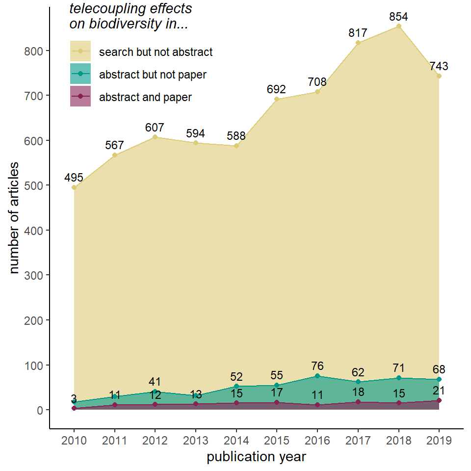

```r
# Get a count of records per year
  paper_ct <- ddply(papers, .(year_pub,type), summarize, count=length(year_pub))

# Change to factors
  paper_ct$year_pub <- as.factor(paper_ct$year_pub)
  paper_ct$type <- factor(paper_ct$type,
                        levels = c('search but not abstract',
                                   'abstract but not paper',
                                   'abstract and paper'))

  papers.fig <- ggplot(paper_ct, aes(x=year_pub, y=count)) +
                  geom_area(position="identity",
                            aes(y=count, fill = type, group = type), alpha=0.6) +
                  geom_point(aes(y =count, color = type, group = type))+
                  geom_line(aes(y =count, color = type, group = type))+
                  geom_text(aes(label=count),size=3,
                            position=position_dodge(.7),
                            vjust=-.7,
                            check_overlap=TRUE)+
                  scale_color_manual(
                  name=expression(italic("telecoupling effects\non biodiversity in...")),
                  values=paper_col)+
                  scale_fill_manual(
                  name=expression(italic("telecoupling effects\non biodiversity in...")),
                  values=paper_col)+
                  xlab("publication year")+
                  ylab("number of articles") + ylim(0,860)+
                  scale_y_continuous(breaks=seq(0,850,100)) +
                  theme_classic()+
                  theme(legend.position = c(0.22,0.87))

# save image
  ggsave(filename=paste0(fig.dir,"Figure_2_papers_over_time.png"),
         plot=papers.fig, height = 5, width = 5)

# show here
  papers.fig
```

### 5.1.2 Acceptance rate at each level of review

Acceptance rate for abstract screening.

```r
# get total abstract acceptance rate
  sum(ab_all$INCLUDE=='YES')/nrow(ab_all)
```

```
## [1] 0.08007117
```

Acceptance rate for papers that were reviewed (**NOTE:** this includes the 5 common surveys).

```r
# get total paper acceptance rate
  sum(survey1$status=='accept')/nrow(survey1)
```

```
## [1] 0.2301184
```

Acceptance rate per person (**NOTE:** this excludes the 5 common surveys per person, but has a rate for it on its own as “all”).

```r
# get summary
  acr <- ddply(survey1, .(coder_id), summarize,
              # total count of entries
              count=length(coder_id),
              accept=sum(status=='accept'),
              reject=sum(status=='reject'),
              # percent acceptance
              accept_rate=sum(status=='accept')/length(coder_id))
  acr
```

| coder_id | count | accept | reject | accept_rate |
| --- | --- | --- | --- | --- |
| A_Herzberger | 63 | 20 | 43 | 0.3174603 |
| A_Torres | 51 | 7 | 44 | 0.1372549 |
| all | 5 | 4 | 1 | 0.8000000 |
| C_Hovis | 92 | 20 | 72 | 0.2173913 |
| E_Dean | 43 | 8 | 35 | 0.1860465 |
| E_Xing | 43 | 9 | 34 | 0.2093023 |
| K_Kapsar | 52 | 11 | 41 | 0.2115385 |
| M_Lei | 43 | 15 | 28 | 0.3488372 |
| MG_Chung | 43 | 7 | 36 | 0.1627907 |
| X_Wu | 67 | 18 | 49 | 0.2686567 |

[output cut: 3 more lines]

Average per-person acceptance rates

```r
# mean per-person acceptance rate
  mean(acr$accept_rate)
```

```
## [1] 0.2469415
```

## 5.2 Themes across accepted papers

Add abstracts to the accepted papers and convert to term matrix.

```r
# fix columns
  assignments$ABSTRACT <- as.character(assignments$ABSTRACT)
  keep$abstract <- NA
  assignments$TITLE <- as.character(assignments$TITLE)
  keep$title <- NA

# get list of values to replace
  pID <- unique(keep$paper_id)

# add abstracts
  for (i in 1:length(pID)){
      keep$abstract[keep$paper_id==pID[[i]]] <-
      assignments$ABSTRACT[assignments$STUDY_ID.1==pID[[i]]]
  }

# add title
  for (i in 1:length(pID)){
      keep$title[keep$paper_id==pID[[i]]] <-
      assignments$TITLE[assignments$STUDY_ID.1==pID[[i]]]
  }

# make into table, save and re-read
  ab_table  <- subset(keep, select=c("title","abstract"))
  write.table(ab_table, paste0(tab.dir,"s1_accepted_abstracts.txt"), sep=" ")
  ab_table <- VCorpus(VectorSource(readLines(paste0(tab.dir,
                                                    "s1_accepted_abstracts.txt"))))

# transform special characters into a space
  toSpace <- content_transformer(function (x , pattern ) gsub(pattern," ",x))
  ab_table <- tm_map(ab_table, toSpace, "/")
  ab_table  <- tm_map(ab_table, toSpace, "@")
  ab_table  <- tm_map(ab_table, toSpace, "\\|")
  ab_table  <- tm_map(ab_table, toSpace, "\t")
  ab_table  <- tm_map(ab_table, toSpace, ",")
  ab_table  <- tm_map(ab_table, toSpace, ";")
  ab_table  <- tm_map(ab_table, toSpace, "_")

# cleanup
  ab_table <- tm_map(ab_table, content_transformer(tolower))
  ab_table <- tm_map(ab_table, removeWords, stopwords("english"))
  ab_table <- tm_map(ab_table, removeWords,
                     c('however','per','also','may', 'elsevier', 'can'))
  ab_table  <- tm_map(ab_table, toSpace, "-")
  ab_table <- tm_map(ab_table, removeNumbers)
  ab_table <- tm_map(ab_table, removePunctuation)
  ab_table <- tm_map(ab_table, stripWhitespace)

# Create term matrix
  term.mtrx <- TermDocumentMatrix(ab_table)
  mtrx <- as.matrix(term.mtrx)
  rows.mtrx <- sort(rowSums(mtrx),decreasing=TRUE)
  abterms.df <- data.frame(word = names(rows.mtrx),freq=rows.mtrx)

# Show frequency of the top 20 terms
  head(abterms.df, 20)
```

|  | word | freq |
| --- | --- | --- |
| species | species | 458 |
| biodiversity | biodiversity | 151 |
| forest | forest | 143 |
| areas | areas | 136 |
| sites | sites | 133 |
| human | human | 121 |
| abundance | abundance | 119 |
| bird | bird | 119 |
| effects | effects | 106 |
| study | study | 106 |

[output cut: 10 more lines]

### 5.2.1 Wordcloud

Next, make a wordcloud.

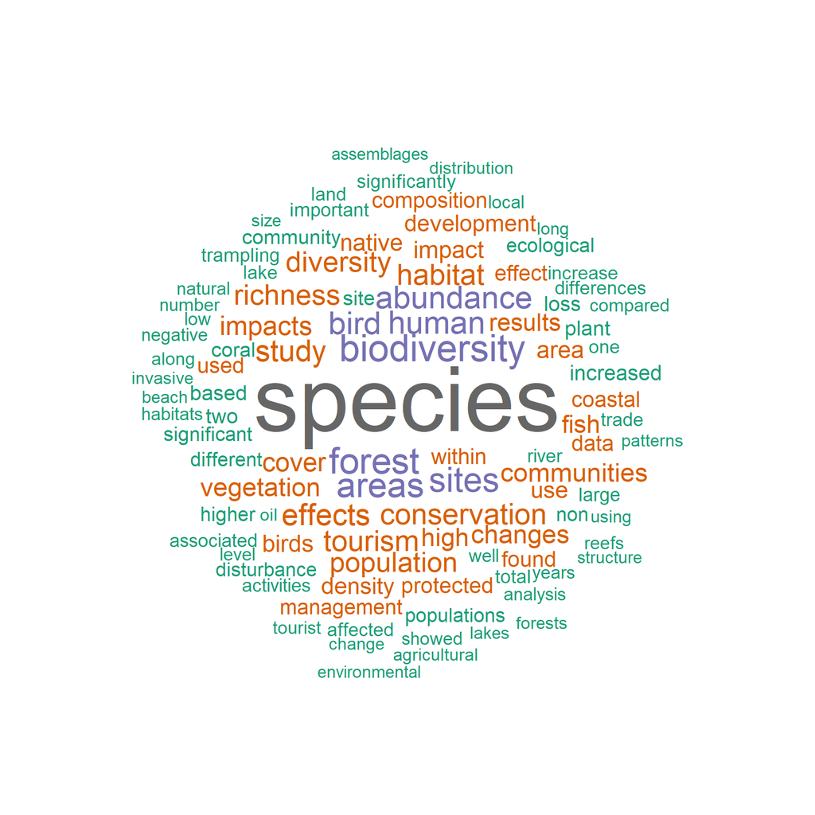

```r
# Word cloud
  png(paste0(fig.dir,"S1_word_cloud.png"),
      height=6,width=6,units='in',res=300)
  par(mar = rep(0, 4))

  set.seed(1234)
  wordcloud(words = abterms.df$word, freq = abterms.df$freq, min.freq = 10,
            max.words=100, random.order=FALSE, rot.per=0.0,
            colors=brewer.pal(8, "Dark2"))
  dev.off()
```

## 5.3 Counts of study types (accepted papers only)

```r
# get summary
  ddply(keep, .(C4_study), summarize,
        # total count of entries
        count=length(C4_study),
        percent=length(C4_study)/nrow(keep))
```

| C4_study | count | percent |
| --- | --- | --- |
| Experimental study | 4 | 0.029411765 |
| Modeling study (using empirical data and not projected) | 11 | 0.080882353 |
| Observational study | 120 | 0.882352941 |
| Observational/Modeling study | 1 | 0.007352941 |

## 5.4 Counts of papers that were inferred (accepted papers only)

Total rate of **inferring** across papers.

```r
# get total papers for which the tc relationships were inferred
  paste('number inferred papers:',sum(keep$explicit_distant_impacts=='No'))
  paste('number explicit papers:',sum(keep$explicit_distant_impacts=='Yes'))

# get total inferring rate
  paste('inferred percent:',sum(keep$explicit_distant_impacts=='No')/nrow(keep))
  paste('explicit percent:',sum(keep$explicit_distant_impacts=='Yes')/nrow(keep))
```

```
## [1] "number inferred papers: 51"
## [1] "number explicit papers: 76"
## [1] "inferred percent: 0.375"
## [1] "explicit percent: 0.558823529411765"
```

Percent of papers inferred per person per person

```r
# get summary
  ddply(keep, .(coder_id), summarize,
        # total count of entries
        count=length(coder_id),
        inferred=sum(explicit_distant_impacts=='No'),
        explicit=sum(explicit_distant_impacts=='Yes'),
        # percent inferred
        inferred_rate=sum(explicit_distant_impacts=='No')/length(coder_id))
```

| coder_id | count | inferred | explicit | inferred_rate |
| --- | --- | --- | --- | --- |
| A_Herzberger | 20 | 9 | 11 | 0.4500000 |
| A_Torres | 7 | 2 | 5 | 0.2857143 |
| all | 4 | 2 | 2 | 0.5000000 |
| C_Hovis | 20 | 6 | 14 | 0.3000000 |
| E_Dean | 8 | 3 | 5 | 0.3750000 |
| E_Xing | 9 | 0 | 0 | 0.0000000 |
| K_Kapsar | 11 | 7 | 4 | 0.6363636 |
| M_Lei | 15 | 6 | 9 | 0.4000000 |
| MG_Chung | 7 | 3 | 4 | 0.4285714 |
| X_Wu | 18 | 2 | 16 | 0.1111111 |

[output cut: 2 more lines]

# 6. Cleaned survey export

```r
# join tables
  survey1 <- bind_rows(keep,reject)

# export
  write.csv(survey1,paste0(dat.dir,'survey1_cleaned.csv'),row.names=FALSE)
```